# Plotting

Zachary McCaw  
Updated: 2024-11-01

## Abstract

This vigentte illustrates plotting cumulative incidence curves for two or more strata.

```r
suppressPackageStartupMessages({
  library(CICs)
  library(dplyr)
  library(ggplot2)
})
```

## Cumulative incidence of the event of interest

### Two-sample setting

Built-in functions are available for the specific setting of comparing the cumulative incidence of the event of interest between two treatment arms.

#### Simulate data

Data are simulated for two treatment arms, a reference arm (`arm == 0`) and a treatment arm (`arm == 1`). Note that the plotting functions assume the arms are labeled 0 and 1.

```r
set.seed(101)
n <- 1e2

# Reference arm.
df0 <- CICs::GenData(
  n = n,
  event_rate = 1.0,
  death_rate = 0.25,
  censor_rate = 0.25,
  tau = 4
)
df0$arm <- 0

# Treatment arm.
df1 <- CICs::GenData(
  n = n,
  event_rate = 0.5,
  death_rate = 0.25,
  censor_rate = 0.25,
  tau = 4
)
df1$arm <- 1

data <- rbind(df0, df1)
```

#### Plotting

The built-in functions provide only the cumulative incidence curve (CIC) for the event of interest (i.e. the event with `status == 1`). To plot both the event of interest and the competing risk, see a subsequent example.

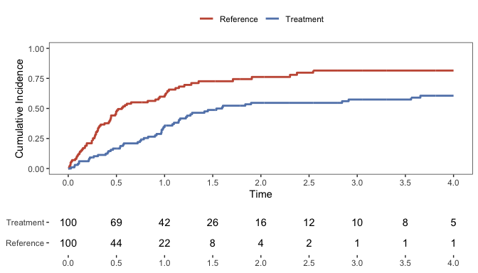

```r
# Set the time points at which to calculate NARs.
# Pass these to both PlotCICs and PlotNARs for consistent labeling.
x_breaks <- seq(from = 0, to = 4, by = 0.5)
x_labs <- sprintf("%.1f", x_breaks)

# Plot the cumulative incidence curves.
q_cic <- CICs::PlotCICs(
  data = data,
  color_labs = c("Reference", "Treatment"),
  x_breaks = x_breaks,
  x_labs = x_labs
)

# Plot the numbers at risk.
q_nar <- CICs::PlotNARs(
  data = data,
  x_breaks = x_breaks,
  x_labs = x_labs,
  y_labs = c("Reference", "Treatment")
)

# Final plot.
q <- cowplot::plot_grid(
  plotlist = list(q_cic, q_nar),
  align = "v",
  axis = "l",
  ncol = 1,
  rel_heights = c(3, 1)
)
show(q)
```

### Stratified setting

Although built-in functions are not available for the stratified setting, the following code can readily be adapted for plotting CICs with NARs for any number of strata.

#### Simulate data

Data are simulated for 3 strata with increasing event rates.

```r
set.seed(102)
n <- 1e2
n_strata <- 3

# Simulate data for each stratum.
data <- lapply(seq_len(n_strata), function(i) {
  df <- CICs::GenData(
    n = n,
    event_rate = i / n_strata,
    death_rate = 0.25,
    censor_rate = 0.25,
    tau = 4
  )
  df$stratum <- i
  return(df)
})
data <- do.call(rbind, data)
```

#### Prepare plotting frames

First calculate the cumulative incidence curves and numbers at risk for each stratum. Below, these are stored as a *list of functions*.

```r
# Calculate CICs.
strata <- sort(unique(data$stratum))
cics <- lapply(strata, function(n){
  cic <- CICs::CICurve(data %>% dplyr::filter(stratum == n))
  return(cic)
})
names(cics) <- strata

# Calculate NARs.
nars <- lapply(strata, function(n){
  nar <- CICs::NARCurve(data %>% dplyr::filter(stratum == n))
  return(nar)
})
names(nars) <- strata
```

Prepare the plotting frame for the cumulative incidence curves.

```r
# Set a dense grid of points at which to evaluate the CICs.
eval_points <- seq(from = 0, to = 4, length.out = 1000)

df_cic <- lapply(strata, function(n) {
  cic_fn <- cics[[n]]
  out <- data.frame(
    time = eval_points,
    cic = cic_fn(eval_points),
    stratum = n
  )
  return(out)
})
df_cic <- do.call(rbind, df_cic)

# Ensure stratum is a factor for plotting.
df_cic$stratum <- factor(
  x = df_cic$stratum,
  levels = sort(unique(df_cic$stratum))
)
```

Prepare the plotting frame for the numbers at risk.

```r
# Choose the points at which to evaluate the NARs.
# Also set the X-axis labels.
x_breaks <- seq(from = 0, to = 4, by = 0.5)
x_labs <- sprintf("%.1f", x_breaks)

df_nar <- lapply(strata, function(n) {
  nar_fn <- nars[[n]]
  out <- data.frame(
    time = x_breaks,
    nar = nar_fn(x_breaks),
    stratum = n
  )
  return(out)
})
df_nar <- do.call(rbind, df_nar)

# Ensure stratum is a factor for plotting.
df_nar$stratum <- factor(
  x = df_nar$stratum,
  levels = sort(unique(df_nar$stratum))
)
```

#### Plotting

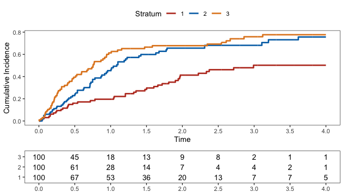

```r
# Common plotting options.
gg_opts <- theme_bw() +
  theme(
    panel.grid.major = ggplot2::element_blank(),
    panel.grid.minor = ggplot2::element_blank(),
    legend.position = "top"
  )

# Plot the cumulative incidence curve.
q_cic <- ggplot(data = df_cic) +
  gg_opts +
  geom_step(
    aes(x = time, y = cic, color = stratum),
    linewidth = 1
  ) +
  scale_x_continuous(
    name = "Time",
    breaks = x_breaks,
    labels = x_labs
  ) +
  scale_y_continuous(
    name = "Cumulative Incidence"
  ) +
  ggsci::scale_color_nejm(
    name = "Stratum"
  )

# Plot the number at risk.
q_nar <- ggplot(data = df_nar) +
  gg_opts +
  geom_text(
    aes(x = time, y = stratum, label = nar)
  ) +
  scale_x_continuous(
    name = NULL,
    breaks = x_breaks,
    labels = x_labs
  ) +
  scale_y_discrete(
    name = NULL
  )

# Final plot.
q <- cowplot::plot_grid(
  plotlist = list(q_cic, q_nar),
  align = "v",
  axis = "l",
  ncol = 1,
  rel_heights = c(3, 1)
)
show(q)
```